# Autoregressive Model

[Nao Mimoto](https://nmimoto.github.io/) - [Dept. of Statistics](http://www.uakron.edu/stat/) : [The University of Akron](http://www.uakron.edu)

[Class Web Page](https://nmimoto.github.io/477/index.html) – [R resource page](https://nmimoto.github.io/R/index.html)

## 1. AR(1) model

- First order autoregression process, AR(1), is defined as
  $$X_t = \phi X_{t-1} + e_t, \hspace10mm \mbox{ where } e_t \sim WN(0,\sigma^2)$$
  and $\phi$ is real-valued constant.
- If $\phi=.8$, then
  $$X_t = (.8) X_{t-1} + e_t$$
- For example, process goes like:

$$\begin{array}{|c|c|c|c|c|c|c|c|}
\hline
t & 0 & 1 & 2 & 3 & 4 & 5 \cdots \\
\hline
\phi X_{t-1} & & .80 & .91 & 1.26 & 0.28 & \cdots\\
e_t & & .34 & .66 & -.91 & -.35 & \cdots\\
\hline
X_t & 1 & 1.14 & 1.57 & 0.35 & -.07 & \cdots\\
\hline
\end{array}$$

- Note that $e_t$ is the only random error (innovation) generated each time.

### Inside AR(1)

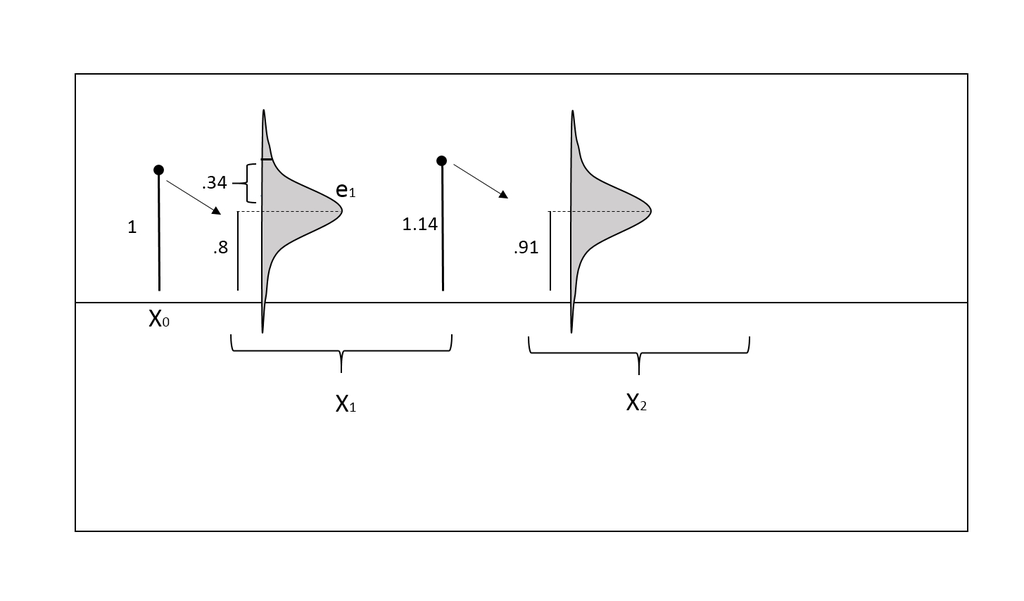

### Questions:

- Is this series stationary? Does $\phi$ has anything to do with the stationarity?
- What is $E(X_t)$, $V(X_t)$ and $\gamma(h)$ of $\rho(h)$ of this process (ACVF and ACF)?

### Stationarity Condition for AR(1)

- We need $|\phi|<1$ for AR(1) process to be stationary.

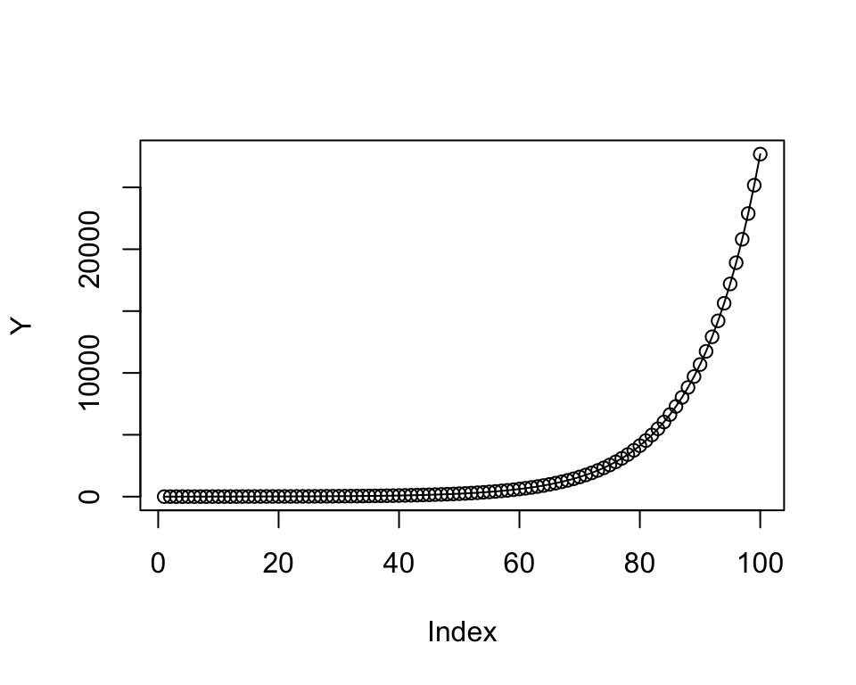

```r
  #- Simulate AR1 with phi > 1
  Y   <- 0.5                     # initial value of Y
  phi <- 1.1              # <--- greater than 1
  e <- rnorm(100, 0, 1)        # generate 100 N(0,1) error
  for (t in 2:100){
    Y[t] = Y[t-1]*phi + e[t]   # compute AR(1) sequence
  }
  plot(Y, type="o")
```

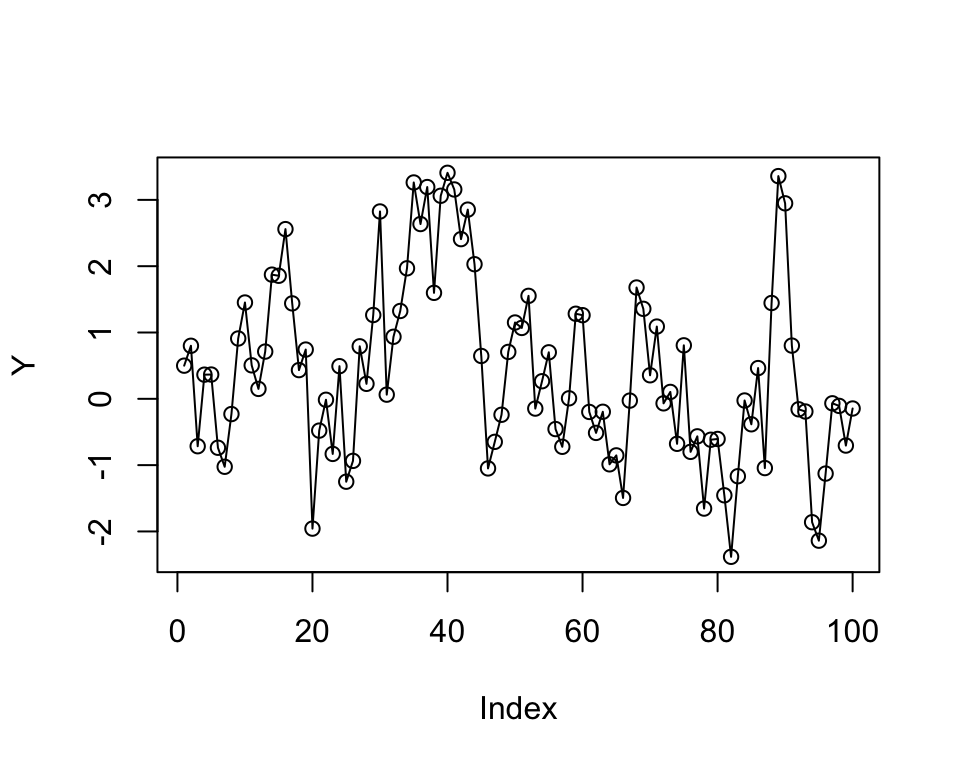

```r
  #- Simulate AR1 with phi<1
  Y   <- 0.5
  phi <- 0.8            # <--- absolute value less than 1
  e <- rnorm(100, 0, 1)        # generate 100 N(0,1) error
  for (t in 2:100){
    Y[t] = Y[t-1]*phi + e[t]   # compute AR(1) sequence
  }
  plot(Y, type="o")
```

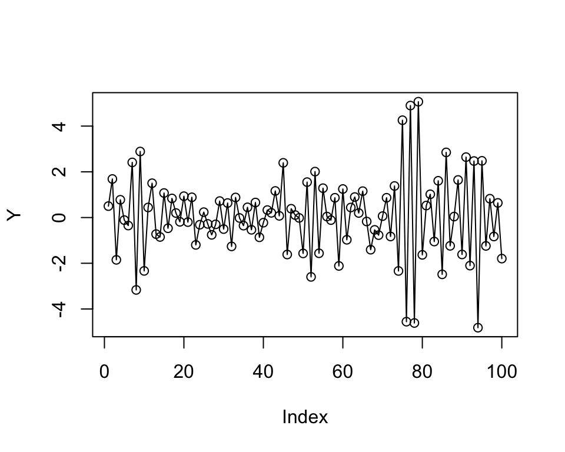

```r
  #- Simulate AR1 with |phi|<1
  Y <- 0.5
  phi <- -0.8           # <--- absolute value less than 1
  e <- rnorm(100, 0, 1)        # generate 100 N(0,1) error
  for (t in 2:100){
    Y[t] = Y[t-1]*phi + e[t]   # compute AR(1) sequence
  }
  plot(Y, type="o")
```

### AR(1) is Random Walk if $\phi=1$

- If $\phi=1$, then
  $$X_t = X_{t-1} + e_t.$$
  This is called **Random Walk**.

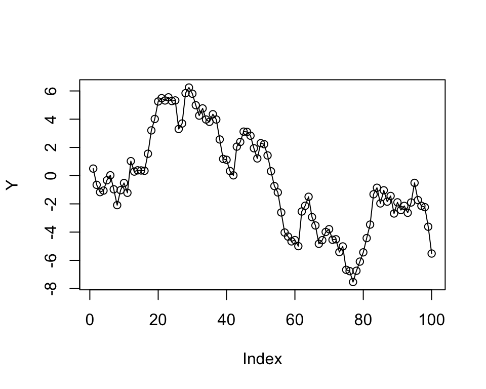

```r
  #- Simulate AR1 with phi=1
  Y <- 0.5
  phi <- 1
  e <- rnorm(100, 0, 1)        # generate 100 N(0,1) error
  for (t in 2:100){
    Y[t] = Y[t-1]*phi + e[t]   # compute AR(1) sequence
  }
  plot(Y, type="o")
```

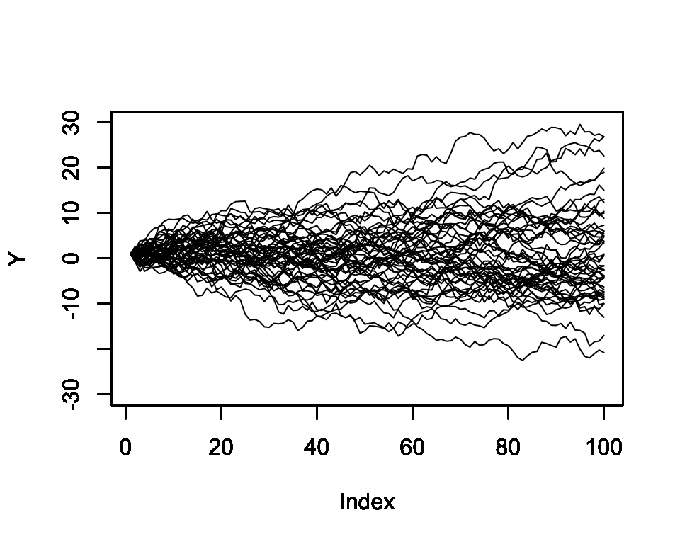

```r
  #- Simulate 50 AR1 with phi=1
  phi <- 1
  for (i in 1:50) {
    Y <- 1
    e <- rnorm(100, 0, 1)        # generate 100 N(0,1) error
    for (t in 2:100){
      Y[t] = Y[t-1]*phi + e[t]   # compute AR(1) sequence
    }
    plot(Y, type="l", ylim=c(-30,30))
    par(new=TRUE)              # overlay all the plot that comes after
  }
```

- **Random Walk** is not a stationary series, because the variance depends on $t$.

## 2. Theoretical ACVF and ACF of AR(1)

- Assume that the AR(1) is stationary. (i.e. $|\phi|<1$)
- What is the theoretical ACVF of AR(1)? Let’s start with variance ($h=0$).

$$\begin{aligned}
\gamma(0) &= \mbox{Var}(X_t) \hspace3mm = \hspace3mm \mbox{Cov}(X_t, X_t) \\\\
&= \mbox{Var}(\phi X_{t-1}+e_t) \hspace20mm
\mbox{ (because $X_{t-1}$ and $e_t$ are independent, ) } \\\\
&= \mbox{Var}(\phi X_{t-1}) + \mbox{Var}(e_t) \\ \\
&= \phi^2 \mbox{Var}(X_{t-1}) \hspace3mm + \hspace3mm \sigma^2
\hspace3mm = \hspace3mm \phi^2 \, \gamma(0) + \sigma^2
\end{aligned}$$

- Given
  $$\gamma(0) \hspace3mm = \hspace3mm \phi^2 \, \gamma(0) + \sigma^2,$$
  solve for $\gamma(0)$, we get formula for variance of $X_t$,
  $$\gamma(0) \hspace3mm = \hspace3mm \frac{ \sigma^2 }{ (1-\phi^2) }.$$
- Do you see what’s wrong if we have $|\phi|>1$?

### When $h=1$

Still assuming the stationarity, let’s look at when $h$ is not 0,
$$\begin{align}
\gamma(1) &= \mbox{Cov}(X_{t+1}, \, X_t) \\ \\
&= \mbox{Cov}\big(\phi \, X_{t} +e_{t+1}, \, \hspace2mm X_t\big) \\ \\
&= \mbox{Cov}\big(\phi \, X_{t}, \, X_t\big)
+ \mbox{Cov}\big(e_{t+1}, \, X_t\big) \\ \\
&= \phi \, \mbox{Cov}(X_t, X_t) \hspace5mm = \hspace2mm \phi\, \gamma(0)
\end{align}$$

### When $h=2$

$$\begin{align}
\gamma(2) &= \mbox{Cov}(X_{t+2}, \, X_t) \\ \\
&= \mbox{Cov}\big(\phi\, X_{t+1} +e_{t+2}, \, \hspace2mm X_t\big) \\ \\
&= \mbox{Cov}\big(\phi\, X_{t+1}, \, X_t\big)
+ \mbox{Cov}\big(e_{t+2}, \, X_t\big) \\ \\
&= \phi\, \mbox{Cov}(X_{t+1}, X_t) \hspace5mm = \hspace2mm \phi\, \gamma(1)
\hspace5mm = \hspace2mm \phi^2 \gamma(0)
\end{align}$$

### ACF and ACVF of AR(1)

- So the ACVF of AR(1) looks like
  $$\gamma(h) =
  \left\{ \begin{array}{ll}
  \frac{ \sigma^2 }{ (1-\phi^2) } & \mbox{ for } h=0 \\\\
  \phi^{|h|} \, \gamma(0) & \mbox{ for } h>0\\
  \end{array} \right.$$
- Then since ACF = ACVF $/\gamma(0)$,
  $$\rho(h) =
  \left\{ \begin{array}{ll}
  1 & \mbox{ for } h=0 \\
  \phi^{|h|} & \mbox{ for } h>0\\
  \end{array} \right.$$

## 3. Theoretical ACVF and ACF of AR(1) in R

- Let $\phi=.8$. i.e. $\hspace5mm \Phi(z) = 1 - .8 z$

```r
  #  install.packages("ltsa")        #- if not installed before

  library(ltsa)                      # load the package ltsa
  Th.ACVF  <- tacvfARMA(phi = c(.8), theta= c(0), maxLag=20, sigma2=1)   # get Theoretical ACVF
  Th.ACVF                            # see what's inside
```

```
##  [1] 2.77777778 2.22222222 1.77777778 1.42222222 1.13777778 0.91022222 0.72817778
##  [8] 0.58254222 0.46603378 0.37282702 0.29826162 0.23860929 0.19088744 0.15270995
## [15] 0.12216796 0.09773437 0.07818749 0.06254999 0.05004000 0.04003200 0.03202560
```

```r
  Th.ACF   <- Th.ACVF / Th.ACVF[1]   # get Theo. ACF
  Th.ACF
```

```
##  [1] 1.00000000 0.80000000 0.64000000 0.51200000 0.40960000 0.32768000 0.26214400
##  [8] 0.20971520 0.16777216 0.13421773 0.10737418 0.08589935 0.06871948 0.05497558
## [15] 0.04398047 0.03518437 0.02814750 0.02251800 0.01801440 0.01441152 0.01152922
```

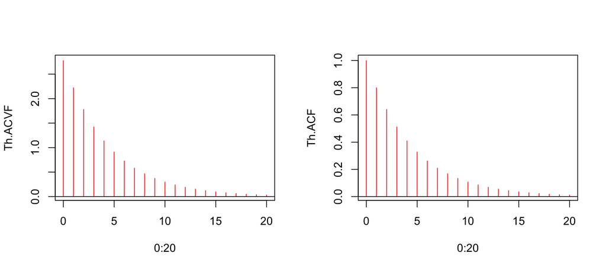

```r
  layout( matrix(1:2, 1,2) )             # two plots side by side
  plot(0:20, Th.ACVF, type="h", col="red")
  abline(h=0)                            # add horizontal line at 0
  plot(0:20, Th.ACF,  type="h", col="red")
  abline(h=0)
```

```r
  #-  Another function for Theoretical ACF  (ACF only, you don't need ltsa package)
  Th.ACF2  <- ARMAacf(ar=c(.8), ma=c(0), lag.max=20, pacf=FALSE )
  Th.ACF2
```

```
##          0          1          2          3          4          5          6          7
## 1.00000000 0.80000000 0.64000000 0.51200000 0.40960000 0.32768000 0.26214400 0.20971520
##          8          9         10         11         12         13         14         15
## 0.16777216 0.13421773 0.10737418 0.08589935 0.06871948 0.05497558 0.04398047 0.03518437
##         16         17         18         19         20
## 0.02814750 0.02251800 0.01801440 0.01441152 0.01152922
```

## 4. Simulation of AR(1)

- Let $\phi=.8$. i.e. $\hspace5mm \Phi(z) = 1 - .8 z$

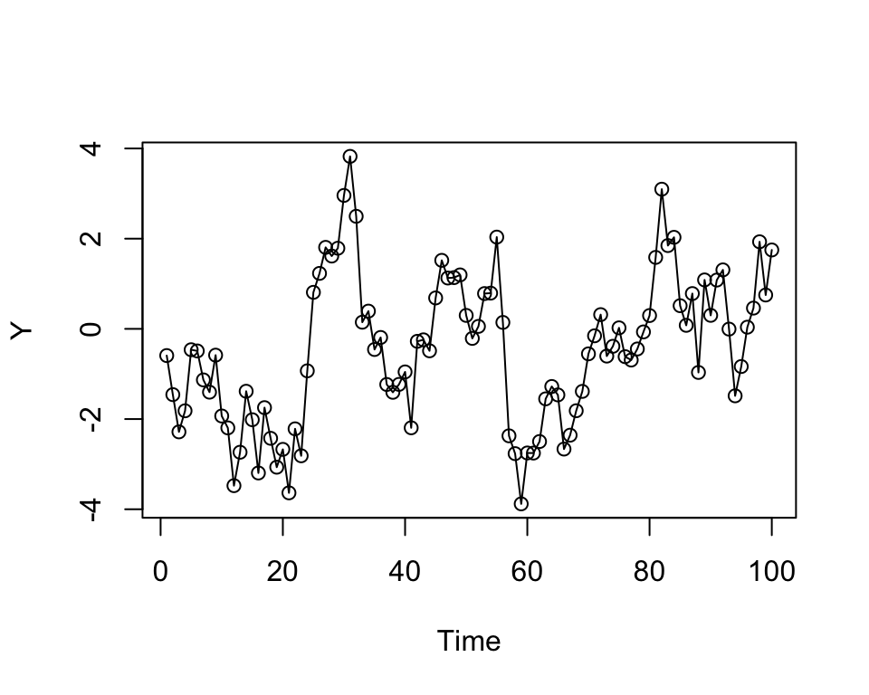

```r
  Y <- arima.sim(list(ar = c(.8 ) ), 100 )         # Simulate AR(1) with phi=.8
  plot(Y, type="o")
```

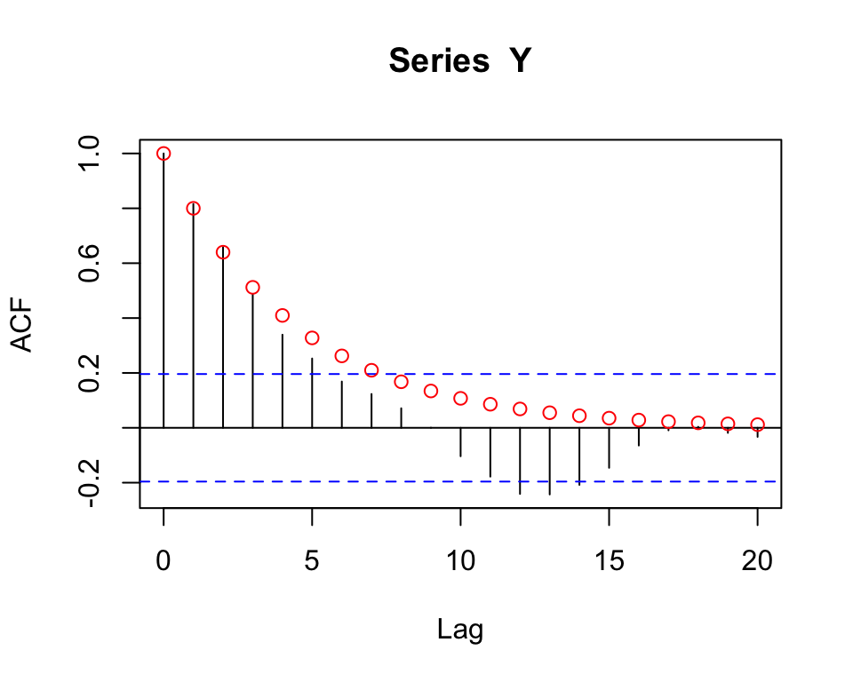

```r
  Th.ACVF1  <- tacvfARMA(phi = c(.8), maxLag=20)   # need library(ltsa)
  Th.ACF1   <- Th.ACVF1 / Th.ACVF1[1]              # get Theoretical ACF

  acf(Y)                                         #- plot sample ACF
  lines(0:20, Th.ACF1, type="p", col="red")      #- overlay theoretical ACF as red circle
```

## Summary

- AR(1) process is defiend by formula
  $$X_t = \phi X_{t-1} + e_t$$
- Which is alternative written using characteristic polynomial and backwards operator,
  $$(1-\phi B) X_t = e_t$$
- $|\phi|$ needs to be less than 1, for AR(1) process to be stationary.
- AR(1) has mean of 0

$$E(X_t) = 0$$

- Theoretical ACF and ACVF of AR(1) are
  $$\gamma(h) =
  \left\{ \begin{array}{ll}
  \frac{ \sigma^2 }{ (1-\phi^2) } & \mbox{ for } h=0 \\\\
  \phi^{|h|} \, \gamma(0) & \mbox{ for } h>0\\
  \end{array} \right.
  \hspace30mm
  \rho(h) =
  \left\{ \begin{array}{ll}
  1 & \mbox{ for } h=0 \\
  \phi^{|h|} & \mbox{ for } h>0\\
  \end{array} \right.$$
- You can simulate AR(1) process, calculate Theoretical and Sample ACF, ACVF with code inside this lecture.